# STAT2401 Analysis of Experiments

Practical Week 5: Solutions

## Learning Check

When you complete this session, you will be able to:

1. calculate confidence intervals for the population regression line $\mu_Y$;
2. calculate prediction $\hat{Y}$ and prediction intervals for the actual value of response;
3. plot confidence and prediction intervals using R;
4. understand the ANOVA related to SLR;
5. interpret the elements in ANOVA R ouput.

Before you start, load the stored datasets provided for exercises below by running the following chunk (assuming the file “Workshop5.Rdata” is saved in the same directory as the .Rmd worksheet).

```
[1] "Anscombe"    "OldFaithful" "wm1"
```

```
  - To create a new chunk: Ctrl+Alt+I (Windows), Cmd+Options+I (MacOs)

  - Attempt this practical using this Rmd file, then rename it as your own file (use File then Save As)

  - Partial solutions will be provided for Questions 3-7.
```

## Question 1: Coarse woody debris (CWD) data

The data for this exercise is concerned with a study of the relationships between coarse woody debris (CWD) and shoreline vegetation and lake development in a sample of 16 lakes in North America. The main variables of interest are the CWD basal area ({CWD.BASA}) against riparian tree density ({RIP.DENS}).

First we set the working directory, load the data, look at its structure (the ~command {str()} is very useful to obtain an idea about what is stored in an object) and look at the data. You can read these data into , and store them as a data frame {CWD}, with the following command:

```r
CWD = read.csv("CWD.csv", header = TRUE)
str(CWD)
```

```
'data.frame':   16 obs. of  3 variables:
 $ LAKE    : chr  "Bay" "Bergner" "Crampton" "Long" ...
 $ RIP.DENS: int  1270 1210 1800 1875 1300 2150 1330 964 961 1400 ...
 $ CWD.BASA: int  121 41 183 130 127 134 65 52 12 46 ...
```

```r
CWD
```

```
         LAKE RIP.DENS CWD.BASA
1         Bay     1270      121
2     Bergner     1210       41
3    Crampton     1800      183
4        Long     1875      130
5       Roach     1300      127
6  Tenderfoot     2150      134
7      Palmer     1330       65
8      Street      964       52
9       Laura      961       12
10  Annabelle     1400       46
11      Joyce     1280       54
12 Lake_hills      976       97
13    Towanda      771        1
14  Black oak      833        4
15    Johnson      883        1
16  Arrowhead      956        4
```

As always it is good to visualise the data. Look at the data frame by simply typing its name, {CWD}. Produce a standard scatterplot of {CWD.BASA} against {RIP.DENS} with

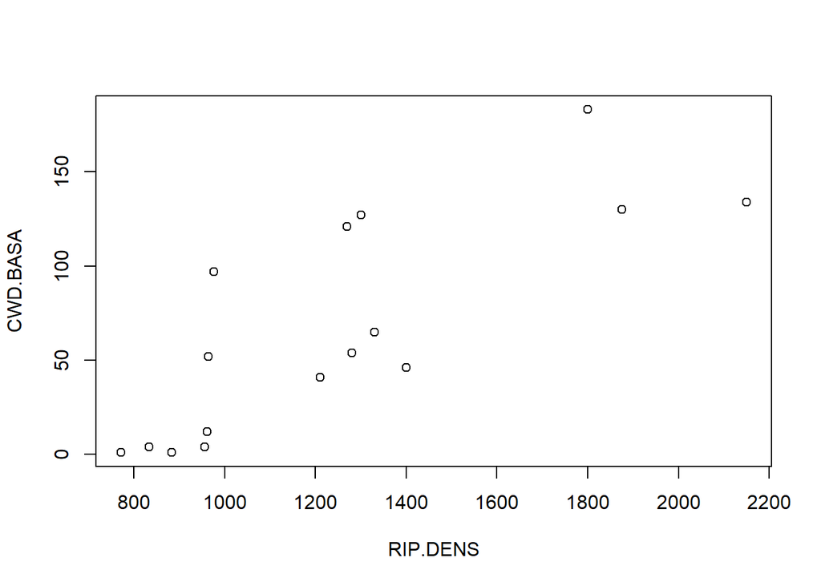

```r
plot(CWD.BASA ~ RIP.DENS, data = CWD)
```

What are your initial impressions?

Initial impressions should be that there is a relationship between {CWD.BASA} and {RIP.DENS}.

Remember we are looking to fit a linear regression to this data. Let’s try it. Fit a simple linear regression model to the data by:

```r
CWD.lm = lm(CWD.BASA ~ RIP.DENS, data = CWD)
summary(CWD.lm)
```

```
Call:
lm(formula = CWD.BASA ~ RIP.DENS, data = CWD)

Residuals:
   Min     1Q Median     3Q    Max
-38.62 -22.41 -13.33  26.16  61.35

Coefficients:
             Estimate Std. Error t value Pr(>|t|)
(Intercept) -77.09908   30.60801  -2.519 0.024552 *
RIP.DENS      0.11552    0.02343   4.930 0.000222 ***
---
Signif. codes:  0 '***' 0.001 '**' 0.01 '*' 0.05 '.' 0.1 ' ' 1

Residual standard error: 36.32 on 14 degrees of freedom
Multiple R-squared:  0.6345,    Adjusted R-squared:  0.6084
F-statistic:  24.3 on 1 and 14 DF,  p-value: 0.0002216
```

The fitted model equation is:
$$\widehat{{CWD.BASA}} = {-77.0991} + {0.1155} \times {RIP.DENS}$$

The percentage of varaition in {CWD.BASA} exaplined by {RIP.DENS} is given by $R^2=0.6345$ or $63.45\%$. The test of the {RIP.DENS} coefficient is statistically significant, indicating evidence against the alternative no linear relationship. An alternative way to determine this is to look at the CI of the coefficient

```r
confint(CWD.lm, level = 0.95)
```

```
                    2.5 %      97.5 %
(Intercept) -142.74672817 -11.4514274
RIP.DENS       0.06525871   0.1657734
```

The 95% confidence interval for the {RIP.DENS} coefficient of is $[0.0653,0.1658]$, that doesn’t include 0.

Lastly, we can draw the confidence interval for the true regression line and prediciton interval for the new values,

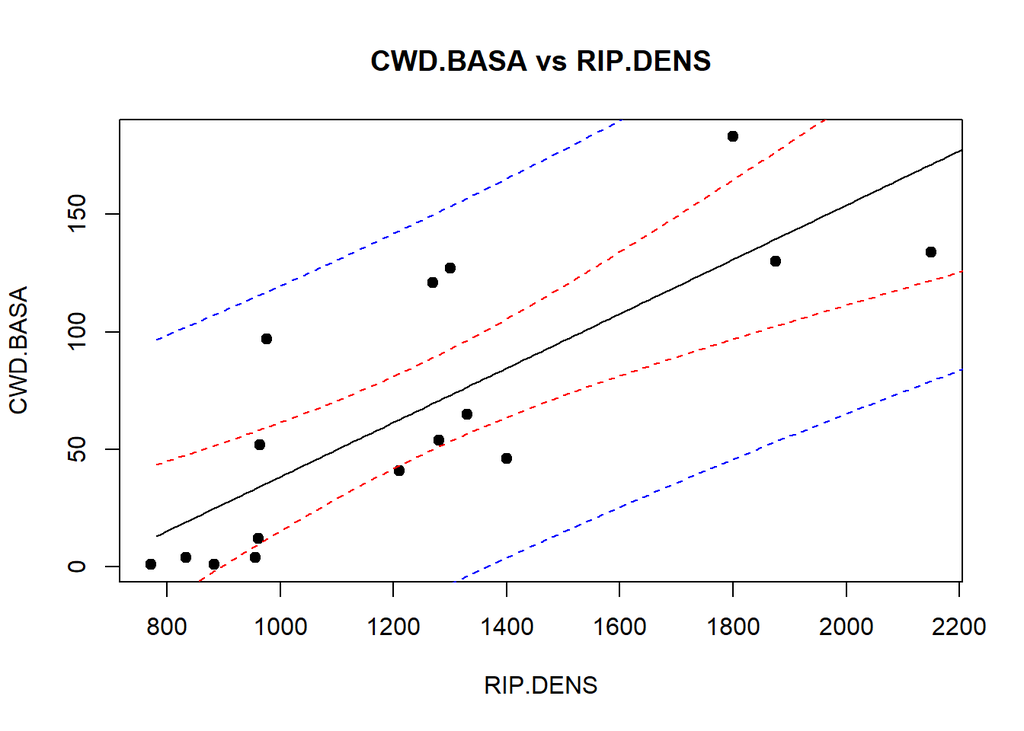

```r
plot(CWD.BASA ~ RIP.DENS, data = CWD, pch = 21, bg = "black", main = "CWD.BASA vs RIP.DENS")
CWD.lm = lm(CWD.BASA ~ RIP.DENS, data = CWD)
new = data.frame(RIP.DENS = seq(780, 2220, 10))
CIs = predict(CWD.lm, new, interval = "confidence")
PIs = predict(CWD.lm, new, interval = "predict")
matpoints(new$RIP.DENS, CIs, lty = c(1, 2, 2), col = c("black", "red", "red"), type = "l")
matpoints(new$RIP.DENS, PIs, lty = c(1, 2, 2), col = c("black", "blue", "blue"),
    type = "l")
```

Say the regression model we have fitted is
$${CWD.BASA} = \beta_0 + \beta_1 \times {RIP.DENS} + \epsilon$$
Take ${RIP.DENS}=1000$, deteremine the fitted value of {CWD.BASA}, the 95% CI for the regression line ${CWD.BASA} = \beta_0 + \beta_1 \times 1000$, and the the 95% PI of a new {CWD.BASA} value.

## Question 2: Macroinvertebrates data

The data for this exercise is concerned with a study that investigates the relationship between the number of species of macroinvertebrates, and the total abundance of macroinvertebrates, and area of clumps of mussels on a rocky shore in southern Australia. The variables of interest are clump area ({AREA}), number of species ({SPECIES}), and number of individuals ({INDIV}).

First we set the working directory, load the data, look at its structure (the ~command {str()} is very useful to obtain an idea about what is stored in an object) and look at the data. You can read these data into , and store them as a data frame {macroinvertebrates}, with the following command:

```r
macroinvertebrates = read.csv("macroinvertebrates.csv", header = TRUE)
str(macroinvertebrates)
```

```
'data.frame':   25 obs. of  3 variables:
 $ AREA   : num  516 469 462 939 1357 ...
 $ SPECIES: int  3 7 6 8 10 9 10 11 16 9 ...
 $ INDIV  : int  18 60 57 100 48 118 148 214 225 283 ...
```

```r
macroinvertebrates
```

```
       AREA SPECIES INDIV
1    516.00       3    18
2    469.06       7    60
3    462.25       6    57
4    938.60       8   100
5   1357.15      10    48
6   1773.66       9   118
7   1686.01      10   148
8   1786.29      11   214
9   3090.07      16   225
10  3980.12       9   283
11  4424.84      13   380
12  4451.68      14   278
13  4982.89      12   338
14  4450.86      14   274
15  5490.74      20   569
16  7476.21      22   509
17  7138.82      15   682
18  9149.94      20   600
19 10133.07      22   978
20  9287.69      21   363
21 13729.13      15  1402
22 20300.77      24   675
23 24712.72      25  1159
24 27144.03      25  1062
25 26117.81      24   632
```

As always it is good to visualise the data. Look at the data frame by simply typing its name, {macroinvertebrates}. Produce a standard scatterplot of {log(SPECIES)} against {log(AREA)}.

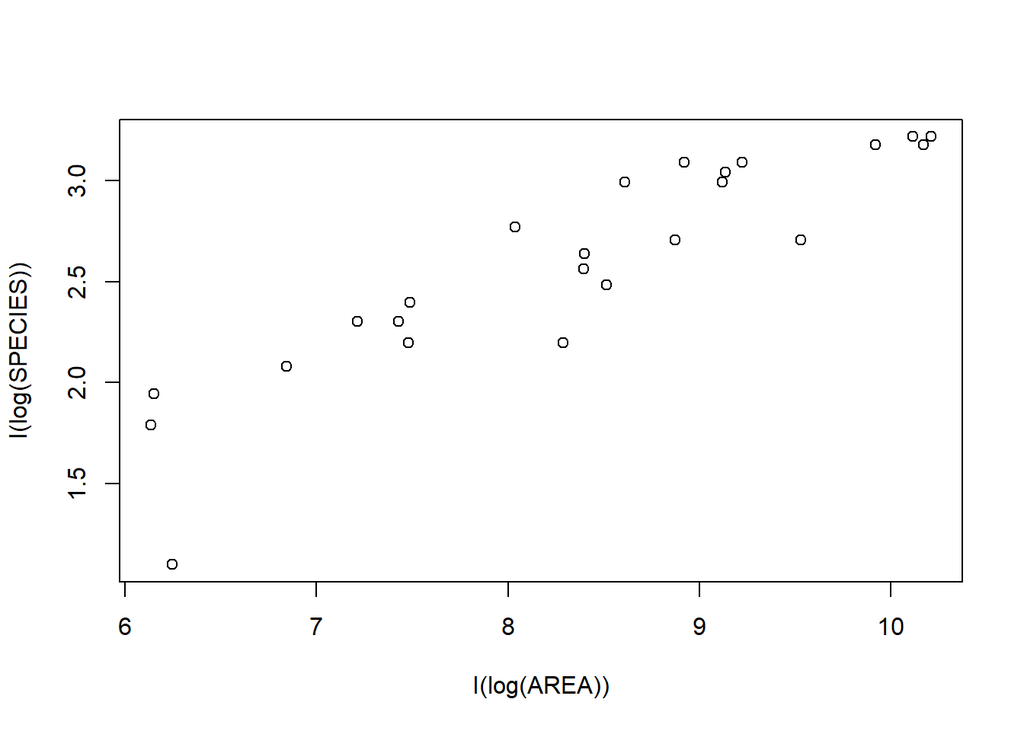

```r
plot(I(log(SPECIES)) ~ I(log(AREA)), data = macroinvertebrates)
```

What are your initial impressions?

Initial impressions should be that there is a relationship between {log(SPECIES)} against {log(AREA)}.

Remember we are looking to fit a linear regression to this data. Let’s try it. Fit a simple linear regression model to the data by:

```r
macroinvertebrates.lm = lm(I(log(SPECIES)) ~ I(log(AREA)), data = macroinvertebrates)
summary(macroinvertebrates.lm)
```

```
Call:
lm(formula = I(log(SPECIES)) ~ I(log(AREA)), data = macroinvertebrates)

Residuals:
     Min       1Q   Median       3Q      Max
-0.68177 -0.08599  0.02731  0.14896  0.30297

Coefficients:
             Estimate Std. Error t value Pr(>|t|)
(Intercept)  -0.62957    0.31882  -1.975   0.0604 .
I(log(AREA))  0.38583    0.03777  10.215 5.11e-10 ***
---
Signif. codes:  0 '***' 0.001 '**' 0.01 '*' 0.05 '.' 0.1 ' ' 1

Residual standard error: 0.2284 on 23 degrees of freedom
Multiple R-squared:  0.8194,    Adjusted R-squared:  0.8115
F-statistic: 104.4 on 1 and 23 DF,  p-value: 5.107e-10
```

The fitted model equation is:
$$\widehat{{log(SPECIES)}} = {-0.6296} + {0.3858} \times {log(AREA)}$$
where $-0.6296$ is the intercept and $0.3858$ is the slope, which would give the change in {log(SPECIES)} as {log(AREA)} is increased by $1$ unit (assuming the model is any good).

We can add the fitted line to the plot by:

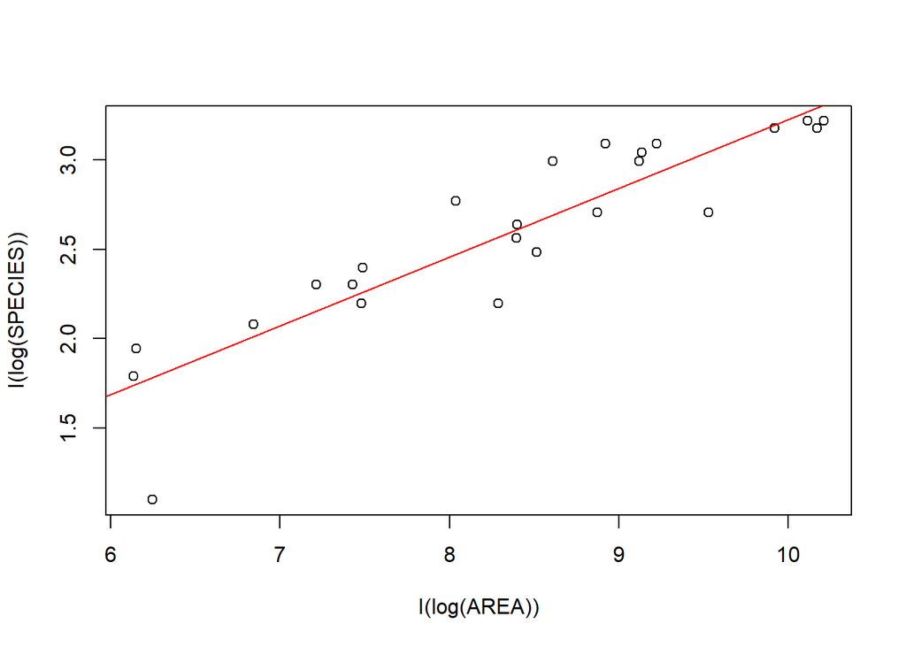

```r
plot(I(log(SPECIES)) ~ I(log(AREA)), data = macroinvertebrates)
abline(coef(macroinvertebrates.lm), col = "red")
```

The fit looks reasonably well.

Here $R^2=0.8194$ and we can show that numerically this is $r^2$ where $r$ correlation coefficient between the independent and dependent variables.

```r
r = with(macroinvertebrates, cor(I(log(SPECIES)), I(log(AREA))))
r^2
```

```
[1] 0.8193995
```

Fit the regression line
$${log(AREA)} = \beta^\prime_0 + \beta^\prime_1 \times {log(SPECIES)} +
\epsilon$$
that is in :

```r
lm(I(log(AREA)) ~ I(log(SPECIES)), data = macroinvertebrates)
```

and check whether $R^2=0.8194$ as well.

## Question 3 The timing of production runs (Sheather, 2009)

The original data are in the form of the time taken (in minutes) for a production run, $Y$, and the number of items produced, $X$, for 20 randomly selected orders as supervised by three managers. At this stage we shall only consider the data for one of the managers.

(a). Open the Excel file *production.txt*.

```r
production = read.table("production.txt", header = T)
View(production)
```

(b). Construct a scatterplot of production run, $Y$, and the number of items produced, $X$. Fit the least squares line to the data using R. Explain the fitted model, by interpreting the slope and intercept.

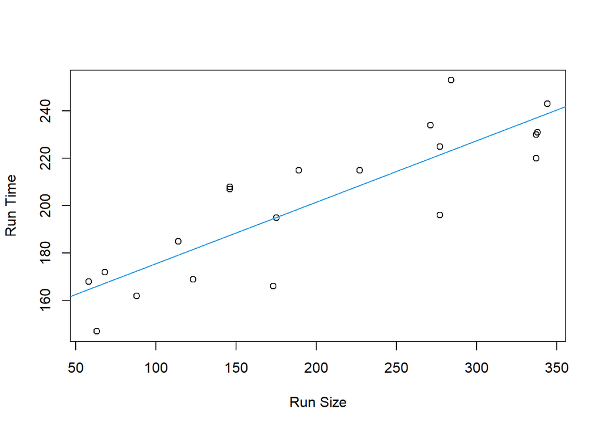

```r
prod.lm = lm(RunTime ~ RunSize, data = production)  ## the LS line
plot(RunTime ~ RunSize, data = production, xlab = "Run Size", ylab = "Run Time")
abline(prod.lm, col = 4)
```

```r
summary(prod.lm)
```

```
Call:
lm(formula = RunTime ~ RunSize, data = production)

Residuals:
    Min      1Q  Median      3Q     Max
-28.597 -11.079   3.329   8.302  29.627

Coefficients:
             Estimate Std. Error t value Pr(>|t|)
(Intercept) 149.74770    8.32815   17.98 6.00e-13 ***
RunSize       0.25924    0.03714    6.98 1.61e-06 ***
---
Signif. codes:  0 '***' 0.001 '**' 0.01 '*' 0.05 '.' 0.1 ' ' 1

Residual standard error: 16.25 on 18 degrees of freedom
Multiple R-squared:  0.7302,    Adjusted R-squared:  0.7152
F-statistic: 48.72 on 1 and 18 DF,  p-value: 1.615e-06
```

The equation of the least squares line of best fit is

$$\hat{y} = 149.7 + 0.26x.$$

The intercept is 149.7, which is where the line of best fit crosses the run time axis. The intercept in the model has the following interpretation: for any production run, the average set up time is 149.7 minutes.

The slope of the line is 0.26. Thus, we say that each additional unit to be produced is predicted to add 0.26 minutes to the run time.

(c). Calculate $Cov(X,Y), Var(X), \bar{X}, \bar{Y}$ of this data. Then use these to validate the above estimates slope and intercept using
$$\hat{\beta}_1 = \frac{Cov(X,Y)}{Var(X)}, \ \
\ \hat{\beta}_0 = \bar{Y} - \hat{\beta}_1\bar{X}$$

```r
sxy = cov(production$RunSize, production$RunTime)  ## sxy=cov(x,y)
sxy
```

```
[1] 2612.539
```

```r
sxx = var(production$RunSize)  ## var(x)
sxx
```

```
[1] 10077.57
```

```r
beta1 = sxy/sxx
beta1
```

```
[1] 0.2592431
```

```r
meanx = mean(production$RunSize)
meanx
```

```
[1] 201.75
```

```r
meany = mean(production$RunTime)
meany
```

```
[1] 202.05
```

```r
beta0 = mean(production$RunTime) - beta1 * mean(production$RunSize)  ## ybar - beta1 * xbar
beta0
```

```
[1] 149.7477
```

(d). Perform a hypothesis testing for a positive slope at a significance level of 5% using the R output in (b).

6 steps hypothesis testing for $\beta_1$:

1. $H_0: \beta_1 = 0, H_1:\beta_1 > 0$
2. The test statistic (from R output as in the above):

$t=\frac{\hat{\beta}_1-0}{se(\hat{\beta}_1)}=\frac{0.25924}{0.03714}=6.98.$

```r
pval = pt(6.98, 18, lower.tail = F)
pval
```

```
[1] 8.071027e-07
```

5. Decision. Given the p-value is very small, less than the significance level, then we strongly reject the null hypothesis.
6. Conclusion. We conclude that the slope is statistically significantly positive.

(e). Perform ANOVA F Test to test whether there is a linear association between Run Time and Run Size.

```r
anova(prod.lm)
```

```
Analysis of Variance Table

Response: RunTime
          Df  Sum Sq Mean Sq F value    Pr(>F)
RunSize    1 12868.4 12868.4  48.717 1.615e-06 ***
Residuals 18  4754.6   264.1
---
Signif. codes:  0 '***' 0.001 '**' 0.01 '*' 0.05 '.' 0.1 ' ' 1
```

6 steps hypothesis testing for $\beta_1$:

1. $H_0: \beta_1 = 0, H_1:\beta_1 \neq 0$
2. The test statistic (from R output as in the above):

$F=\frac{MSR}{MSE}=\frac{12868.4}{264.1}=48.717.$

Notice that the observed F -value of 48.717 is just the square of the observed t -value 6.98 which can be found in (d).

(f). Estimate $\sigma^2.$

The point estimate is the residual variance

$$s^2 = \frac{SSE}{(n-2)}=
\frac{4754.6}{18}=264.1=MSE.$$

(g). Calculate the 95% confidence intervals for both parameters slope and intercept respectively.

```r
round(confint(prod.lm, level = 0.95), 3)
```

```
              2.5 %  97.5 %
(Intercept) 132.251 167.244
RunSize       0.181   0.337
```

We are 95% confident that the population slope of this context is between 0.181 and 0.337.

We are 95% confident that the population intercept of this context is between 132.251 and 167.244.

(h). Calculate the 95% confidence intervals for the population regression line $\mu_Y$ (i.e., the average Run Time) at Run Size = 50, 100, 150, 200, 250, 300, 350.

```r
conf.mean0 = predict(prod.lm, newdata = data.frame(RunSize = c(50, 100, 150, 200,
    250, 300, 350)), interval = "confidence", level = 0.95)
conf.mean0
```

```
       fit      lwr      upr
1 162.7099 148.6204 176.7994
2 175.6720 164.6568 186.6872
3 188.6342 179.9969 197.2714
4 201.5963 193.9600 209.2326
5 214.5585 206.0455 223.0714
6 227.5206 216.7006 238.3407
7 240.4828 226.6220 254.3435
```

We can also calculate the 95% confidence intervals for the population regression line $\mu_Y$ using the x (Run Size) as follows.

```r
conf.mean = predict(prod.lm, interval = "confidence", level = 0.95)
conf.mean
```

```
        fit      lwr      upr
1  195.1152 187.2000 203.0305
2  198.7447 191.0450 206.4443
3  238.9273 225.4549 252.3998
4  172.5611 160.8529 184.2693
5  179.3014 169.0456 189.5572
6  237.3719 224.2825 250.4613
7  220.0026 210.6487 229.3565
8  194.5968 186.6389 202.5546
9  223.3727 213.3984 233.3471
10 221.5580 211.9261 231.1900
11 237.1126 224.0865 250.1387
12 164.7838 151.2147 178.3529
13 187.5972 178.8097 196.3847
14 221.5580 211.9261 231.1900
15 181.6346 171.8338 191.4354
16 208.5959 200.7107 216.4811
17 166.0800 152.8317 179.3284
18 237.1126 224.0865 250.1387
19 187.5972 178.8097 196.3847
20 167.3762 154.4448 180.3077
```

Then we add the lower and upper bounds on the same scatterplot as shown below.

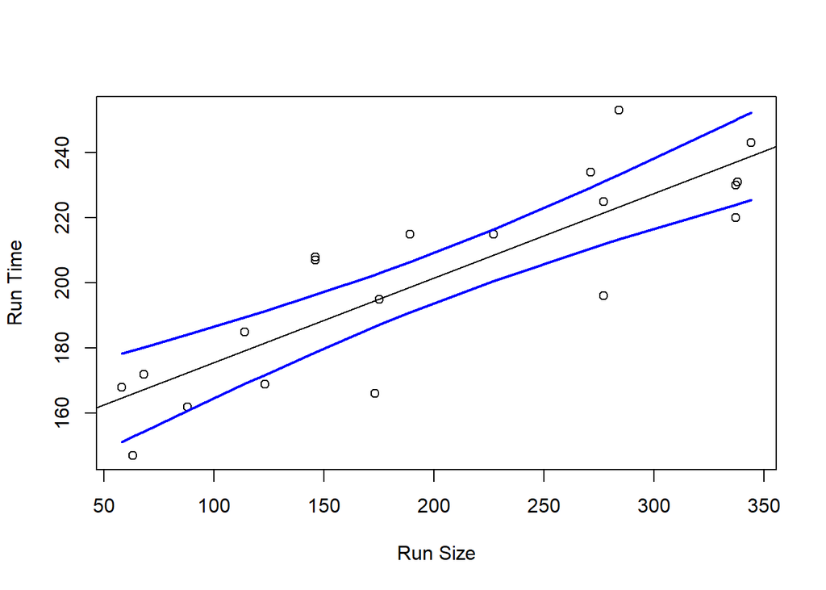

```r
plot(RunTime ~ RunSize, data = production, xlab = "Run Size", ylab = "Run Time")
abline(prod.lm)
matlines(sort(production$RunSize), conf.mean[order(production$RunSize), 2:3], lwd = 2,
    col = "blue", lty = 1)
```

(i). Calculate the 95% percent prediction intervals for the actual value of $Y$ (i.e., the actual Run Time) at at Run Size = 50, 100, 150, 200, 250, 300, 350.

```r
conf.pred0 = predict(prod.lm, newdata = data.frame(RunSize = c(50, 100, 150, 200,
    250, 300, 350)), interval = "prediction", level = 0.95)
conf.pred0
```

```
       fit      lwr      upr
1 162.7099 125.7720 199.6478
2 175.6720 139.7940 211.5500
3 188.6342 153.4135 223.8548
4 201.5963 166.6076 236.5850
5 214.5585 179.3681 249.7489
6 227.5206 191.7021 263.3392
7 240.4828 203.6315 277.3340
```

Similarly, we can also calculate the 95% prediction intervals for the population regression line $\mu_Y$ using the x (Run Size) as follows.

```r
conf.pred = predict(prod.lm, interval = "prediction", level = 0.95)
conf.pred
```

```
        fit      lwr      upr
1  195.1152 160.0646 230.1659
2  198.7447 163.7421 233.7472
3  238.9273 202.2204 275.6343
4  172.5611 136.4643 208.6578
5  179.3014 143.6493 214.9536
6  237.3719 200.8038 273.9400
7  220.0026 184.5993 255.4058
8  194.5968 159.5365 229.6570
9  223.3727 187.8005 258.9450
10 221.5580 186.0803 257.0358
11 237.1126 200.5671 273.6581
12 164.7838 128.0413 201.5263
13 187.5972 152.3394 222.8550
14 221.5580 186.0803 257.0358
15 181.6346 146.1107 217.1585
16 208.5959 173.5520 243.6397
17 166.0800 129.4547 202.7053
18 237.1126 200.5671 273.6581
19 187.5972 152.3394 222.8550
20 167.3762 130.8644 203.8881
```

Notice that each prediction interval is considerably wider than the corresponding confidence interval, as is expected.

Note that the confidence interval and prediction interval using the expressions of Lecture 7:

- the standard error of prediction at some value of the explanatory variable $x_{*}$ is given by
  $$\mbox{se}(\hat{y}_*) = s\left( 1 + \frac{1}{n} +
  \frac{(x_* - \bar{x})^2}{S_{XX}} \right)^{1/2}$$
- and so a $95\%$ prediction interval would be given by
  $$\hat{y}_* \pm
  t_{0.025, n-2} \times \mbox{se}(\hat{y}_*)$$

In these expressions,
$$\hat{y}_* =
\hat{\beta}_0 + \hat{\beta}_1 x_*, \ \ S_{XX} = \sum_{i=1}^n (x_i -
\bar{x})^2$$
.

Therefore each prediction interval is considerably wider than the corresponding confidence interval, as is expected.

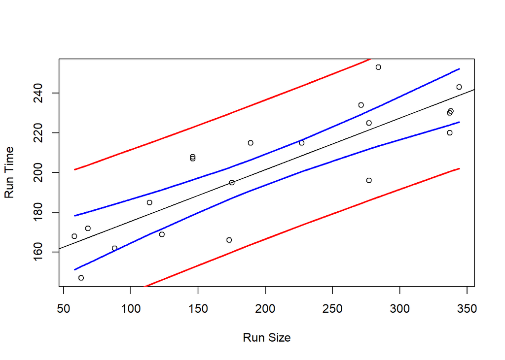

```r
plot(RunTime ~ RunSize, data = production, xlab = "Run Size", ylab = "Run Time")
abline(prod.lm)
matlines(sort(production$RunSize), conf.pred[order(production$RunSize), 2:3], lwd = 2,
    col = "red", lty = 1)
matlines(sort(production$RunSize), conf.mean[order(production$RunSize), 2:3], lwd = 2,
    col = "blue", lty = 1)
```

(j). Coefficient of determination. The value of $R^2= 0.7302$ (from R output line 51, multiple R-squared) which implies that 73.02% of the information (variation) in Run Time is explained by the least squares regression line, suggesting that the model is a good model.

You can also use $R^2=SSR/SST$ using the ANOVA table,

$$R^2=\frac{12868}{17623}=0.7302$$

## Question 4 Wind data (From Weisberg, S. (2005). *Applied Linear Regression*, 3rd edition. New York: Wiley)

In this question, you will be learning the R code in more detail to provide better visualisation which may be needed for your project. Furthermore, the ANOVA is explained in more detail following the lecture (part c).

The *R* data file `Wind.RData` contains a data frame (`wm1`) containing wind speed data (in m/s) at two sites: a reference site (`Rspd`) and a candidate site (`CSpd`). Data were collected every 6 hours for the year 2002 except in the month of May. The objective is to be able to determine whether wind speed at the reference site, which has permanent wind speed monitoring equipment, can be used to predict the wind speed at this candidate site in the future in order to determine whether to place a small wind farm there.

```r
# Load the workshop data here
load("Wind.RData")
```

1. Draw a scatterplot of the response `CSpd` against the predictor `RSpd` and label it appropriately. Is a simple linear model plausible for these data?

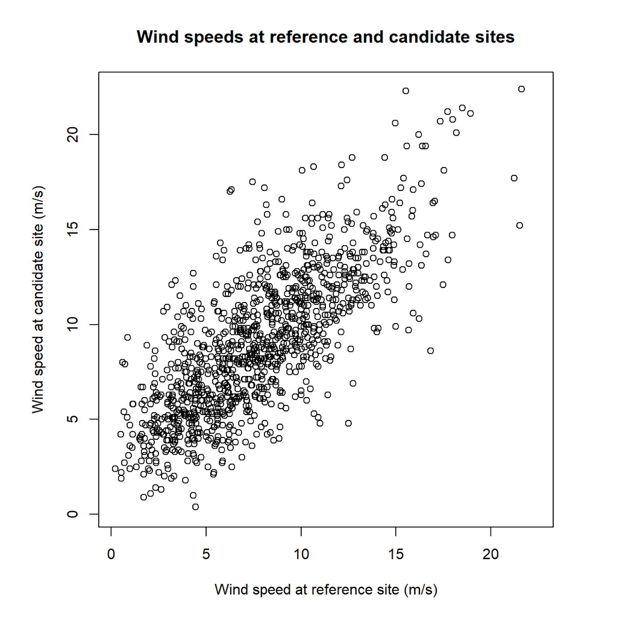

```r
par(pty = "s")  # A graphical parameter that sets the PlotTYpe to 'square'

# The syntax of the plot statement says 'plot CSpd against RSpd but extract
# them from the data frame wm1. The xlim and ylim arguments are the same - the
# range of all the data.
plot(CSpd ~ RSpd, data = wm1, xlab = "Wind speed at reference site (m/s)", ylab = "Wind speed at candidate site (m/s)",
    main = "Wind speeds at reference and candidate sites", xlim = range(c(wm1$CSpd,
        wm1$RSpd)), ylim = c(range(c(wm1$CSpd, wm1$RSpd))))
```

2. Fit a simple linear model to these data, and present the appropriate regression summaries. Plot the fitted line onto the plot in (a).

```r
# Notice the similarity with the plot statement above
Wind.lm <- lm(CSpd ~ RSpd, data = wm1)
# Here are the contents of the object Wind.lm:
names(Wind.lm)
```

```
 [1] "coefficients"  "residuals"     "effects"       "rank"
 [5] "fitted.values" "assign"        "qr"            "df.residual"
 [9] "xlevels"       "call"          "terms"         "model"
```

```r
# and here's some basic output:
Wind.lm
```

```
Call:
lm(formula = CSpd ~ RSpd, data = wm1)

Coefficients:
(Intercept)         RSpd
     3.1412       0.7557
```

```r
# A bit more comes from the summary() function:
summary(Wind.lm)
```

```
Call:
lm(formula = CSpd ~ RSpd, data = wm1)

Residuals:
    Min      1Q  Median      3Q     Max
-7.7877 -1.5864 -0.1994  1.4403  9.1738

Coefficients:
            Estimate Std. Error t value Pr(>|t|)
(Intercept)  3.14123    0.16958   18.52   <2e-16 ***
RSpd         0.75573    0.01963   38.50   <2e-16 ***
---
Signif. codes:  0 '***' 0.001 '**' 0.01 '*' 0.05 '.' 0.1 ' ' 1

Residual standard error: 2.466 on 1114 degrees of freedom
Multiple R-squared:  0.5709,    Adjusted R-squared:  0.5705
F-statistic:  1482 on 1 and 1114 DF,  p-value: < 2.2e-16
```

*To plot the fitted line onto an existing plot in R or RStudio, you only need to invoke the `abline` command (from the console) that we’ve used already and that’s shown below. Here, however, because I want to produce a separate plot from the one above, I have to re-plot the data using the above commands and then invoke `abline`.*

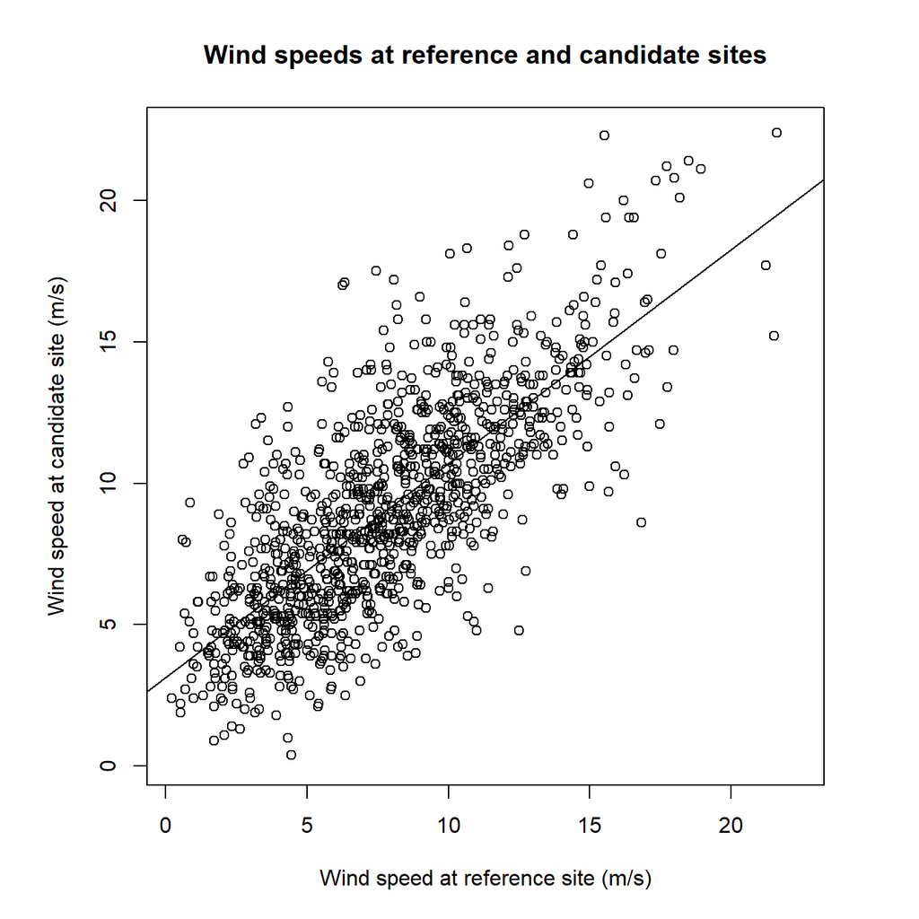

```r
par(pty = "s")
plot(CSpd ~ RSpd, data = wm1, xlab = "Wind speed at reference site (m/s)", ylab = "Wind speed at candidate site (m/s)",
    main = "Wind speeds at reference and candidate sites", xlim = range(c(CSpd, RSpd)),
    ylim = c(range(c(CSpd, RSpd))))
# abline() takes two arguments: a slope and an intercept. We can extract these
# from the object Wind.lm (which is a list) by using the $ operator, e.g.,
# Wind.lm$coefficients (try it!) and using that as an argument to abline():
abline(Wind.lm$coef)  # or simply abline(Wind.lm)
```

3. The ANOVA table shows you the decomposition of the total sum of squares into the residual sum of squares and the regression sum of squares, but use the appropriate vectors containing the data and the fitted values to confirm this decomposition.

The total sum of squares (SST, the overall variability in $y$) is given by
$$\sum_{i=1}^n (y_i - \bar{y})^2$$
,

where $y$ represents the response variable, which in our case is `CSpd`. In R, we can calculate SST as follows:

```r
SST <- sum((wm1$CSpd - mean(wm1$CSpd))^2)
SST
```

```
[1] 15791.34
```

Remember that R works does vector arithmetic. In the expression above, I’ve put some additional spaces so you can see more clearly that we square the differences first, and then sum them. If you’re not sure what that expression does, break it down into steps. I could have extracted the variable `CSpd` first, e.g., `CSpd <- wm1$CSpd` and then used it in the expression above.*

We could extract the residuals from the linear model object `Wind.lm` and then calculate the residual sum of squares (RSS) by squaring and then summing them, but let’s do the basic calculation using the vector of fitted values (the $\hat{y}_i$) that we can also extract from `Wind.lm`, i.e.,

$$\mbox{SSE} = \sum_{i=1}^n (y_i -
\hat{y}_i)^2$$
.

```r
SSE <- sum((wm1$CSpd - Wind.lm$fitted)^2)
SSE  # Check in ANOVA table!
```

```
[1] 6775.695
```

To calculate the regression sum of squares (SSReg), we use the expression $\sum_{i=1}^n (\hat{y}_i - \bar{y})^2$, and in R this is just*

```r
SSReg <- sum((Wind.lm$fitted - mean(wm1$CSpd))^2)
SSReg  # Check in ANOVA table!
```

```
[1] 9015.65
```

*You can see that `SST = SSReg + RSS`, and that $R^2$ (as calculate by the `summary()` function) is `SSReg/SST` (try it out!).*

```r
anova(Wind.lm)
```

```
Analysis of Variance Table

Response: CSpd
            Df Sum Sq Mean Sq F value    Pr(>F)
RSpd         1 9015.6  9015.6  1482.3 < 2.2e-16 ***
Residuals 1114 6775.7     6.1
---
Signif. codes:  0 '***' 0.001 '**' 0.01 '*' 0.05 '.' 0.1 ' ' 1
```

4. Obtain and plot a 95% prediction interval. What is the 95% prediction interval for `CSpd` when `RSpd` takes on a value of 7.4285 m/s?

*To obtain and plot a prediction interval (and the confidence interval for the mean), we use the function `predict`. We also saw it’s use in Lecture 7, so I’ll just show the code here. Again, I’m going to re-plot the data and the fitted line, but if you were doing this in RStudio and you had the previous plot showing, you would not have to do so. I don’t expect you to remember these commands and reproduce them in a test; however, you will (likely) need the for the mini-project that constitutes the third assessment.*

```r
par(pty = "s")
plot(CSpd ~ RSpd, data = wm1, xlab = "Wind speed at reference site (m/s)", ylab = "Wind speed at candidate site (m/s)",
    main = "Confidence and prediction intervals for wind data", xlim = range(c(CSpd,
        RSpd)), ylim = c(range(c(CSpd, RSpd))))
abline(Wind.lm$coef)

# Obtain a 95% confidence interval for the population regression line
ConfMean <- predict(Wind.lm, interval = "confidence")  # 95% is the default
head(ConfMean)
```

```
       fit      lwr      upr
1 7.650391 7.489626 7.811156
2 8.595813 8.449367 8.742260
3 9.142133 8.997145 9.287120
4 7.688782 7.528856 7.848708
5 7.800026 7.642419 7.957633
6 4.477898 4.204884 4.750912
```

```r
# Don't worry too much about these plotting statements
matlines(sort(wm1$RSpd), ConfMean[order(wm1$RSpd), 2:3], lwd = 2, col = "blue", lty = 1)

# Obtain a 95% prediction interval
PredInt <- predict(Wind.lm, interval = "prediction")
head(PredInt)
```

```
       fit        lwr       upr
1 7.650391  2.8087331 12.492049
2 8.595813  3.7546098 13.437017
3 9.142133  4.3009733 13.983292
4 7.688782  2.8471522 12.530412
5 7.800026  2.9584722 12.641580
6 4.477898 -0.3687856  9.324581
```

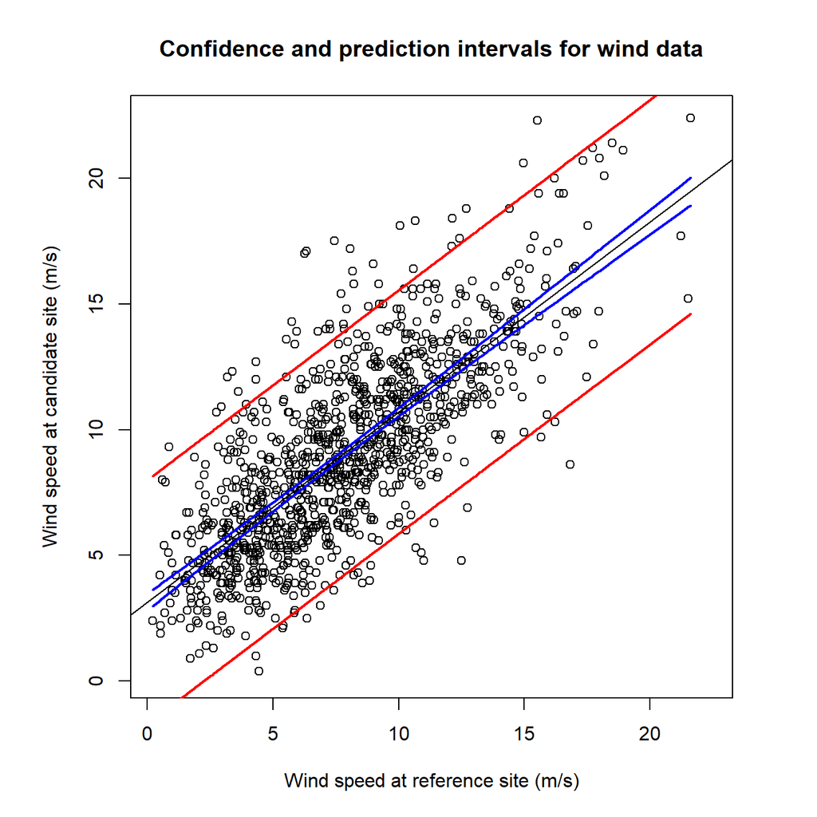

```r
# Don't worry too much about these plotting statements
matlines(sort(wm1$RSpd), PredInt[order(wm1$RSpd), 2:3], lwd = 2, col = "red", lty = 1)
```

*Using the function `predict()`, we can get the 95% prediction interval for `CSpd` when `RSpd` is at a value of 7.4285 m/s. Here’s the syntax:*

```r
predict(object = Wind.lm, newdata = data.frame(RSpd = 7.4285), interval = "prediction")
```

```
       fit      lwr      upr
1 8.755197 3.914023 13.59637
```

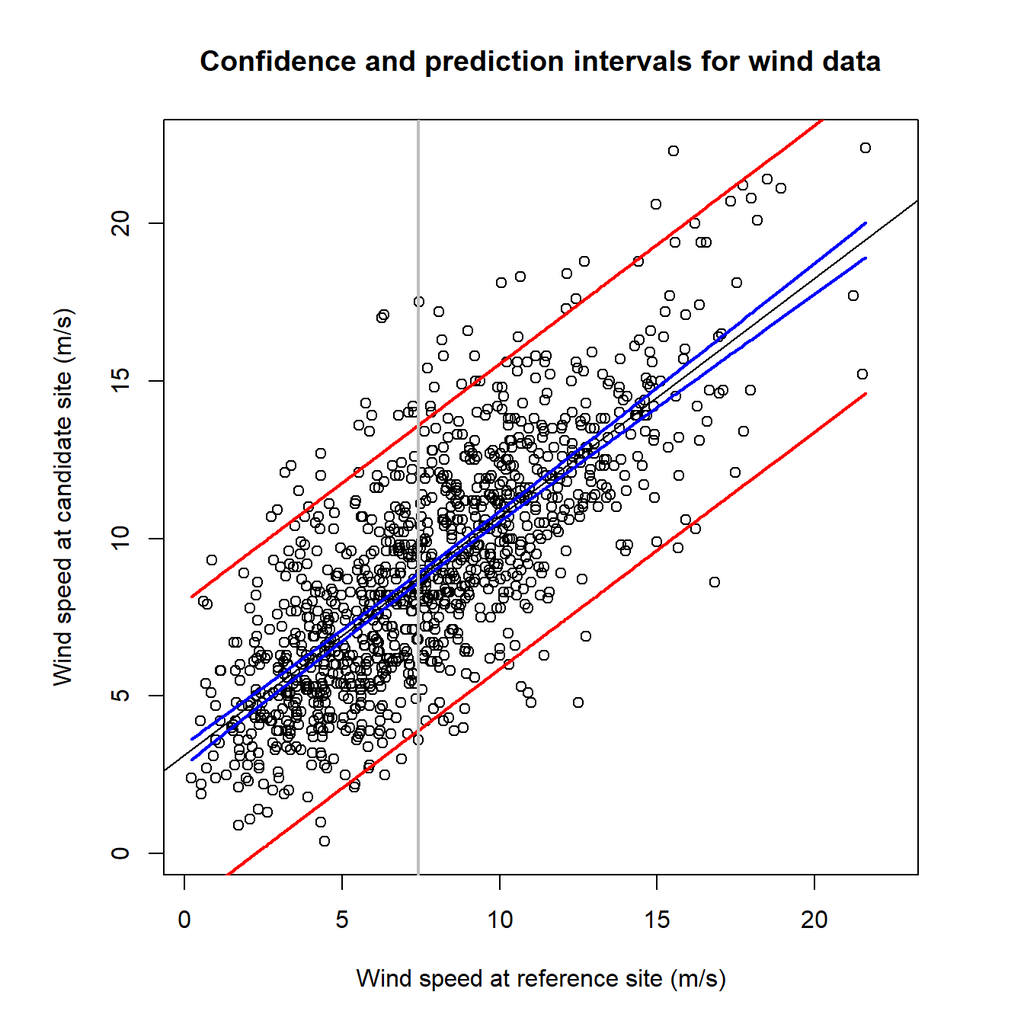

```r
par(pty = "s")
plot(CSpd ~ RSpd, data = wm1, xlab = "Wind speed at reference site (m/s)", ylab = "Wind speed at candidate site (m/s)",
    main = "Confidence and prediction intervals for wind data", xlim = range(c(CSpd,
        RSpd)), ylim = c(range(c(CSpd, RSpd))))
abline(Wind.lm$coef)

matlines(sort(wm1$RSpd), ConfMean[order(wm1$RSpd), 2:3], lwd = 2, col = "blue", lty = 1)

matlines(sort(wm1$RSpd), PredInt[order(wm1$RSpd), 2:3], lwd = 2, col = "red", lty = 1)

# plots a (v for) vertical line at 7.4285 with double the usual LineWiDth
abline(v = 7.4285, col = "grey", lwd = 2)
```

## Question 5 Invoices data (Sheather, 2009)

The manager of the purchasing department of a large company would like to develop a regression model to predict the average amount of time it takes to process a given number of invoices. Over a 30-day period, data are collected on the number of invoices processed and the total time taken (in hours). The data are available in the file *invoices.txt.*

Complete the following tasks.

(a). Fit the least squares line to the data using R. Explain the fitted model, by interpreting the slope and intercept.

```r
invoices = read.table("invoices.txt", header = T)
View(invoices)
```

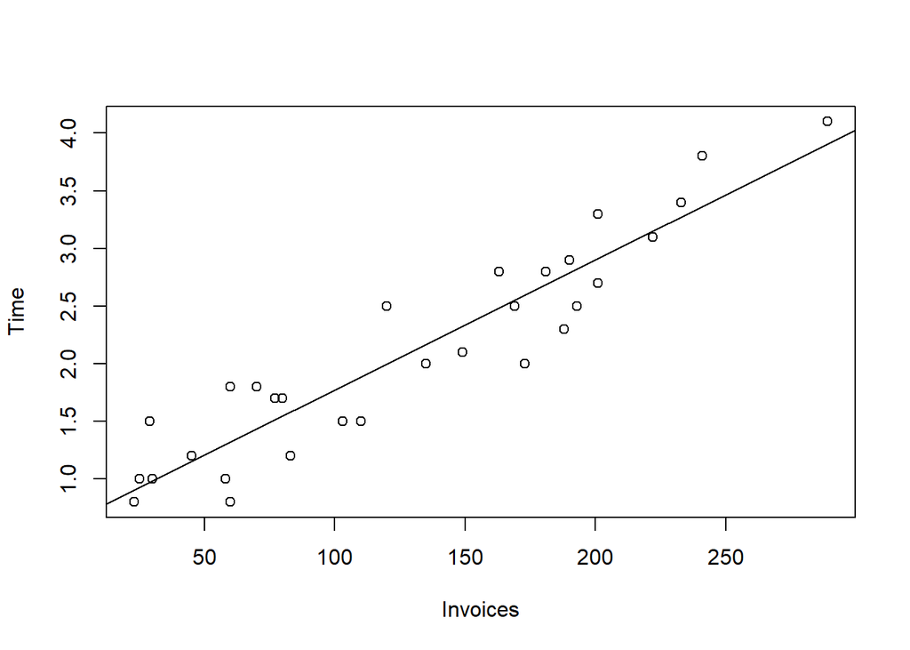

```r
inv.lm = lm(Time ~ Invoices, data = invoices)
plot(Time ~ Invoices, data = invoices)
abline(inv.lm)
```

```r
summary(inv.lm)
```

```
Call:
lm(formula = Time ~ Invoices, data = invoices)

Residuals:
     Min       1Q   Median       3Q      Max
-0.59516 -0.27851  0.03485  0.19346  0.53083

Coefficients:
             Estimate Std. Error t value Pr(>|t|)
(Intercept) 0.6417099  0.1222707   5.248 1.41e-05 ***
Invoices    0.0112916  0.0008184  13.797 5.17e-14 ***
---
Signif. codes:  0 '***' 0.001 '**' 0.01 '*' 0.05 '.' 0.1 ' ' 1

Residual standard error: 0.3298 on 28 degrees of freedom
Multiple R-squared:  0.8718,    Adjusted R-squared:  0.8672
F-statistic: 190.4 on 1 and 28 DF,  p-value: 5.175e-14
```

The equation of the least squares line of best fit is

$$Time= 0.642 + 0.011
Invoices.$$

The intercept is 0.642, which is not interpretable for no invoices.

The slope of the line is 0.011. Thus, we say for that for each additional invoice, the average amount of time it takes to process increases by 0.011 hour.

(b). Find a 95% confidence interval for the start-up time, i.e. $\beta_0$

```r
round(confint(inv.lm, level = 0.95), 3)
```

```
            2.5 % 97.5 %
(Intercept) 0.391  0.892
Invoices    0.010  0.013
```

(c). Suppose that a best practice benchmark for the average processing time for an additional invoice is 0.01 hours (or 0.6 minutes). Test the null hypothesis $\beta_1=0.01$ against a two-sided alternative. Interpret your result.

6 steps hypothesis testing for $\beta_1$:

1. $H_0: \beta_1 = 0.01, H_1:\beta_1 \not= 0.01$
2. The test statistic (from R output as in the above):

$t=\frac{\hat{\beta}_1-0.01}{se(\hat{\beta}_1)}=\frac{0.011-0.01}{0.0008}=1.22.$

```r
tstat = (0.011 - 0.01)/(0.0008184)
tstat
```

```
[1] 1.221896
```

```r
pval = 2 * pt(1.22, 28, lower.tail = F)
pval
```

```
[1] 0.2326413
```

5. Decision. Given the p-value is large, p-value > 5% significance level, then we do not reject the null hypothesis.
6. Conclusion. We conclude that the population slope is 0.01.
4. Find a point estimate and a 95% prediction interval for the time taken to process 130 invoices.

```r
predict(object = inv.lm, newdata = data.frame(Invoices = 130), interval = "prediction")
```

```
       fit      lwr    upr
1 2.109624 1.422947 2.7963
```

(e). The value of $R^2= 0.8718$ which implies that 87.18% of the information (variation) in processing time is explained by the least squares regression line, suggesting that the model is a good model.

## Question 6 Concept for ANOVA

We are interested in fitting a simple linear regression

$$y = \beta_0 + \beta_1 x + \epsilon$$

where $\epsilon$ is normally distributed with mean 0 and variance $\sigma^2$.

Use the following statistics $\sum_{i=1}^n x_i = 250$, $\sum_{i=1}^n x_i^2 = 2250$, $\sum_{i=1}^n y_i^2 = 3546$, $\sum_{i=1}^n y_i = 350$, $\sum_{i=1}^n x_iy_i = 2750$, and $n=50$, determine all elements in the analysis of variance table numerically

$$\begin{array}{cccccc}
\text{Source of} & \text{Degrees of} & \text{Sum of squares}
& \text{Mean square} & \text{F-value} & \text{Pr($>F$)}
\\
\text{variation} & \text{freedom (df)} & \text{(SS)} &
\text{(MS)} & & \\
\hline
\text{Regression} & 1 & \text{RegSS} &
\frac{\text{RegSS}}{1} &
\frac{\text{RegSS}/1}{\text{RSS}/(n-2)}& \\
\text{Residual} & n-2 & \text{RSS} &
\frac{\text{RSS}}{n-2} & &\\
\text{Total} & n-1 & \text{TSS} & \frac{\text{TSS}}{n-1}
& &\\
\end{array}$$

Test for significance of the regression at the level 5% and also determine the $R^2$.

Use the equality $\text{TSS}=\text{RSS}+\text{RegSS}$, we can compute RegSS, RSS and TSS

$$\text{TSS} = \sum_{i=1}^n (y_i-\overline{y})^2\\
\text{RSS} = \sum_{i=1}^n (y_i-\widehat{y}_i)^2\\
\text{RegSS} = \sum_{i=1}^n (\widehat{y}_i-\overline{y})^2
~=~\widehat{\beta}_1^2\sum_{i=1}^n (x_i-\overline{x})^2$$

Again, we first compute

$$\overline{x} = \frac{1}{n}\sum_{i=1}^n x_i = \frac{250}{50} = 5\\
\overline{y} = \frac{1}{n}\sum_{i=1}^n y_i = \frac{350}{50} = 7\\
\sum_{i=1}^n (y_i-\overline{y})^2
=
\sum_{i=1}^n y_i^2- n\overline{y}^2
= 3546 - 50\times 7^2 = 1096
\\
\sum_{i=1}^n (x_i-\overline{x})^2
=
\sum_{i=1}^n x_i^2- n\overline{x}^2
= 2250- 50\times 5^2 = 1000
\\
\sum_{i=1}^n (x_i-\overline{x})(y_i-\overline{y})
=
\sum_{i=1}^n x_iy_i- n\overline{x}\overline{y}
= 2750- 50\times 5\times 7 = 1000$$

So we have

$$\widehat{\beta}_1 = \frac{\sum_{i=1}^n
(x_i-\overline{x})(y_i-\overline{y})}{\sum_{i=1}^n (x_i-\overline{x})^2}
= \frac{1000}{1000} = 1
%\\ \widehat{\beta}_0 &=& \overline{y}-\widehat{\beta}_1
\overline{x}=7- 1\times 5 = 2$$

Therefore

$$\text{TSS} = \sum_{i=1}^n (y_i-\overline{y})^2 = 1096\\
\text{RegSS} = \sum_{i=1}^n (\widehat{y}_i-\overline{y})^2
~=~\widehat{\beta}_1^2\sum_{i=1}^n (x_i-\overline{x})^2 ~=~ 1^2\times
1000\\
\text{RSS} = \text{TSS} - \text{RegSS} = 1096 - 1000 = 96$$

So we have

$$\begin{array}{cccccc}
\text{Source of} & \text{Degrees of} & \text{Sum of squares}
& \text{Mean square} & \text{F-value} & \text{Pr($>F$)}
\\
\text{variation} & \text{freedom (df)} & \text{(SS)} &
\text{(MS)} & & \\
\hline
\text{Regression} & 1 & 1000 & 1000 &
\frac{1000}{2}=500& 0\\
\text{Residual} & n-2=48 & 96 &
\frac{96}{48}=2 & &\\
\text{Total} & n-1=49 & 1096 & \frac{1096}{49}=22.3674
& &\\
\end{array}$$

The F-statistic is 500 with degrees of freedom 1 and 48, the $p$-value can be found using {R}

```r
1 - pf(500, 1, 48)
```

```
[1] 0
```

To test for signifiance of the regression, that is test H$_0:\beta_1=0$ vs H$_1:\beta_1\neq0$ for the simple linear regression. the F-statistic is given by

$$\frac{\text{RegSS}/1}{\text{RSS}/(n-2)} =
\frac{\sum_{i=1}^n (\widehat{y}_i-\overline{y})^2}{\widehat{\sigma}^2} =
\frac{\widehat{\beta}_1^2\sum_{i=1}^n
(x_i-\overline{x})^2}{\widehat{\sigma}^2} =
\Big(
\frac{\widehat{\beta}_1}{\sqrt{\widehat{Var}(\widehat{\beta}_1)}}
\Big)^2$$

So for the simple linear regression, this F-statistic is equal to the $($t-statistic$)^2$

$$\frac{\text{RegSS}/1}{\text{RSS}/(n-2)} = 500 =
\Big(\frac{1}{\sqrt{0.002}}\Big)^2
=
\Big(
\frac{\widehat{\beta}_1}{\sqrt{\widehat{Var}(\widehat{\beta}_1)}}
\Big)^2$$

So $p$-value $<0.05$ and we reject H$_0$ at the 5% significance level.

Lastly, $R^2$ is given by

$$R^2
= 1-\frac{\text{RSS}}{\text{TSS}}
= 1-\frac{96}{1096} = 0.9124088$$